# Integrando e aproveitando o melhor de Python e R

Guilherme Hathy

13/12/2023

# Sobre mim

- Bacharel em Estatística - UFPR
- Mestrando no Programa de Pós-Graduação em Métodos Numéricos - UFPR
- Apaixonado por programação e Aprendizado Estatístico de Máquina
- CTO e Data Scientist na La Decora

# R

- Desenvolvido por Ross Ihaka e Robert Gentleman na Universidade de Auckland, Nova Zelândia, em 1993
- R 1.0.0 (2000)
- Inspirado na linguagem S
- Foco:
  - Inicialmente voltada para estatística e análise de dados
  - Amplamente utilizado em estatística, análise exploratória de dados e visualização
- Comunidade:
  - Forte presença na comunidade acadêmica e em pesquisas científicas.
  - Pacotes extensivos desenvolvidos por estatísticos e pesquisadores.

# Python

- Criado por Guido van Rossum e lançado em 1991
- Inicialmente projetado como uma linguagem de propósito geral
- Foco:
  - Ampla aplicabilidade, desde desenvolvimento web até automação e análise de dados
  - Popular para aprendizado de máquina e inteligência artificial
- Comunidade:
  - Grande e diversificada comunidade de desenvolvedores
  - Bibliotecas como NumPy, Pandas e Matplotlib impulsionam a análise de dados.
  - Com grande suporte para computação em nuvem

# Qual é o melhor?

[figure not shown]

# Imagine que você é um contruto?

[figure not shown]

# O melhor dos dois mundos

- Python é uma **linguagem de propósito geral** de alto nível que se tornou popular em um específico domínio. Com muitas ferramentas para data science e machine learning com bibliotecas como Numpy, Pandas e SciKit-Learn.
- R foi criada para ser uma **linguagem voltada para estatística e análise de dados** mas que vem crescendo como uma linguagem de propósito geral. A Comunidade R vem desenvolvendo muitas ferramentas para fazer deploy em produção.

# Reticulate - Chamando o Python dentro do R

O reticulate é um pacote do R que realiza uma integração entre sessões do R e Python

- Chama o Python dentro de scripts R. Podendo importar modulos do Python direto para uma sessão R
- Faz a transição entre R e Python objetos (Exemplo: R data frame para pandas data frame)
- Flexibilidade na escolha de versões do Python utilizando virtual environments e Conda environments

## Hands On!

Primeiro precisamos instalar o pacote

```r
install.packages('reticulate')
```

Além do pacote `reticulate`, também é necessário instalar o Python.

```r
library('reticulate')
```

### Main functions

- `reticulate::repl_python()` - Abrir um python repl dentro do R console
- `reticulate::import()` - Importar o modulo Python para o R
- `reticulate::py_install()` - Instalar python modules
- `reticulate::source_python()` - Executar um Python script dentro do R
- `r.` e `py$` para acessar as variáveis

O pacote faz automaticamente a conversão:

Single-element vector $\rightarrow$ Scalar

Multi-element vector $\rightarrow$ List

List of multiple types $\rightarrow$ Tuple

Named list $\rightarrow$ Dict

Matrix/Array $\rightarrow$ NumPy ndarray

Data Frame $\rightarrow$ Pandas DataFrame

Function $\rightarrow$ Python function

NULL, TRUE, FALSE $\rightarrow$ None, True, False

## Verificando as conversões

```python
def converter(x):
  print(x)
  return x
```

```r
py$converter(FALSE)
```

```
## False
```

```
## [1] FALSE
```

```r
py$converter(c(1,2,3))
```

```
## [1.0, 2.0, 3.0]
```

```
## [1] 1 2 3
```

```r
py$converter(list(1L, TRUE, "foo"))
```

```
## [1, True, 'foo']
```

```
## [[1]]
## [1] 1
##
## [[2]]
## [1] TRUE
##
## [[3]]
## [1] "foo"
```

```r
py$converter(matrix(c(1,2,3,4), nrow = 2, ncol = 2))
```

```
## [[1. 3.]
##  [2. 4.]]
```

```
##      [,1] [,2]
## [1,]    1    3
## [2,]    2    4
```

```r
py$converter(data.frame(x = c(1,2,3), y = c("a", "b", "c")))
```

```
##      x  y
## 0  1.0  a
## 1  2.0  b
## 2  3.0  c
```

```
##   x y
## 1 1 a
## 2 2 b
## 3 3 c
```

## Fazendo importação de um modulo Python

A função `import` pode ser usada para importar funções do Python para o R.

```r
os <- import("os")
os$listdir(".")
```

```
##  [1] ".Rhistory"                "bank.csv"
##  [3] "GSAF5.xls"                "airline-passengers.csv"
##  [5] "apresentação - cópia.Rmd" "apresentação.Rmd"
##  [7] "README.md"                "img"
##  [9] "teste.py"                 "apresentação.html"
## [11] ".git"
```

## Executar um Python script dentro do R

```r
source_python("teste.py")
```

## Instalação de um pacote no Python

```r
reticulate::py_install("pandas")
```

```
## Using virtual environment '/Users/guilhermehathy/.virtualenvs/r-reticulate' ...
```

```
## + /Users/guilhermehathy/.virtualenvs/r-reticulate/bin/python -m pip install --upgrade --no-user pandas
```

```r
reticulate::py_install("xlrd")
```

```
## Using virtual environment '/Users/guilhermehathy/.virtualenvs/r-reticulate' ...
```

```
## + /Users/guilhermehathy/.virtualenvs/r-reticulate/bin/python -m pip install --upgrade --no-user xlrd
```

## Sharks data

Vamos dar uma olhada na base sharks

```python
import pandas as pd
import numpy as np

sharks = pd.read_excel("GSAF5.xls")
sharks.columns
```

```
## Index(['Date', 'Year', 'Type', 'Country', 'State', 'Location', 'Activity',
##        'Name', 'Sex', 'Age', 'Injury', 'Unnamed: 11', 'Time', 'Species ',
##        'Source', 'pdf', 'href formula', 'href', 'Case Number', 'Case Number.1',
##        'original order', 'Unnamed: 21', 'Unnamed: 22'],
##       dtype='object')
```

Modificando o nome das colunas

```r
library(tidyverse)
py$sharks <- py$sharks %>%
  janitor::clean_names() %>%
  unique() %>%
  filter(!is.na("Case Number"))
```

```python
sharks = sharks \
.rename(columns={'unnamed_11': 'fatal_y_n'})
sharks.columns
```

```
## Index(['date', 'year', 'type', 'country', 'state', 'location', 'activity',
##        'name', 'sex', 'age', 'injury', 'fatal_y_n', 'time', 'species',
##        'source', 'pdf', 'href_formula', 'href', 'case_number', 'case_number_1',
##        'original_order', 'unnamed_21', 'unnamed_22'],
##       dtype='object')
```

```python
sharks = sharks.filter(
  ['case_number', 'country', 'activity', 'fatal_y_n']
  ).query(
  'country in ["USA", "AUSTRALIA"] & activity == "Surfing"'
  ).replace(to_replace='None', value=np.nan).dropna()
```

```python
sharks = sharks.assign(
  fatal_y_n = lambda x: x.fatal_y_n == 'Y'
)
```

## Tabela com os nossos dados

```r
library(gt)
py$sharks %>%
  gt() %>%
  tab_header(
    title = "Data frame limpo"
  )
```

Data frame limpo

| case_number | country | activity | fatal_y_n |
| --- | --- | --- | --- |
| 2022.08.31 | AUSTRALIA | Surfing | FALSE |
| 2022.07.20 | USA | Surfing | FALSE |
| 2022.07.19.a | USA | Surfing | FALSE |
| 2022.07.13.a | USA | Surfing | FALSE |
| 2022.07.10 | USA | Surfing | FALSE |
| 2022.07.03.b | USA | Surfing | FALSE |
| 2022.05.27 | AUSTRALIA | Surfing | FALSE |
| 2022.03.15 | AUSTRALIA | Surfing | FALSE |
| 2022.03.13 | USA | Surfing | FALSE |
| 2022.03.08 | AUSTRALIA | Surfing | FALSE |
| 2022.02.11 | USA | Surfing | FALSE |
| 2022.01.01 | AUSTRALIA | Surfing | FALSE |
| 2021.12.04 | USA | Surfing | FALSE |
| 2021.10.04 | USA | Surfing | FALSE |
| 2021.10.03.a | USA | Surfing | FALSE |
| 2021.09.09 | USA | Surfing | FALSE |
| 2021.09.05 | AUSTRALIA | Surfing | TRUE |
| 2021. 08.21 | USA | Surfing | FALSE |
| 2021..08.07.b | USA | Surfing | FALSE |
| 2021.07.27.b | USA | Surfing | FALSE |
| 2021.07.23 | USA | Surfing | FALSE |
| 2021.07.19 | AUSTRALIA | Surfing | FALSE |
| 2021.07.05 | AUSTRALIA | Surfing | FALSE |
| 2021.06.28 | USA | Surfing | FALSE |
| 2021.06.23 | AUSTRALIA | Surfing | FALSE |
| 2021.05.18 | AUSTRALIA | Surfing | TRUE |
| 2021.05.03 | USA | Surfing | FALSE |
| 2021.04.30 | USA | Surfing | FALSE |
| 2021.02.06 | USA | Surfing | FALSE |
| 2021.01.03 | USA | Surfing | FALSE |

[output cut: 804 more lines]

## Proporção de ataques por país

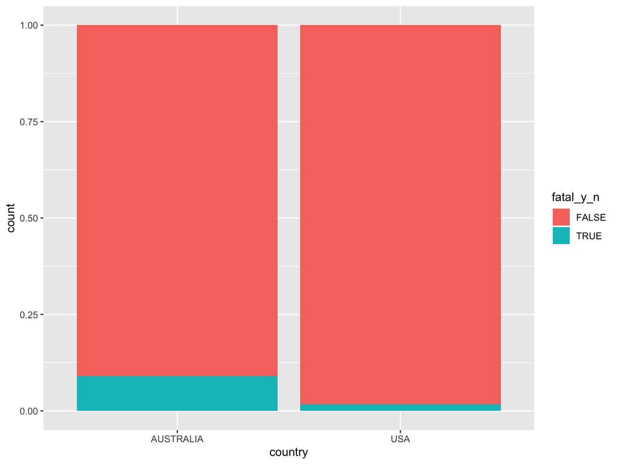

```r
py$sharks %>%
  mutate_all(unlist) %>%
  ggplot(
    aes(x = country, fill = fatal_y_n)
  ) +
    geom_bar(
      position = 'fill'
    )
```

## Uma última tabela, agrupando por país

```python
sharks_country = sharks. filter(
  ['country',
  'fatal_y_n']
).groupby(['country']).agg(['sum']).reset_index()
```

```r
py$sharks_country %>%
  gt() %>%
  tab_header(
    title = "Ataques por país"
  )
```

Ataques por país

| country | fatal_y_n sum |
| --- | --- |
| AUSTRALIA | 20 |
| USA | 10 |

# R2Py - Chamando o R dentro do Python

- Agora vamos utilizar o R dentro de um script Python
- Para instalar o pacote podemos utilizar o comando

```
pip3 install rpy2
```

```python
import rpy2
import rpy2.situation
import rpy2.robjects as ro
from rpy2.robjects import pandas2ri
import pandas as pd
from rpy2.robjects import r


pandas2ri.activate()
```

Agora, vamos importar pacotes do R para dentro do Python.

```python
from rpy2.robjects.packages import importr
import rpy2.robjects.packages as pkgs

r_base = importr('base')
r_utils = importr('utils')
```

## Instalando e importando pacotes

```python
# r_utils.install_packages("fortunes")
ftns = pkgs.importr("fortunes")
ftn7 = ftns.fortune(7)
print(ftn7)
```

[output not shown]

## Exemplo airline

```python
df = pd.read_csv("airline-passengers.csv")
df.head()
```

```
##      Month  Passengers
## 0  1949-01         112
## 1  1949-02         118
## 2  1949-03         132
## 3  1949-04         129
## 4  1949-05         121
```

## Converter dados para o formato R:

```python
rdf = pandas2ri.py2rpy(df)
```

```python
r_base.mean(rdf[1])
```

```
## array([280.29861111])
```

# Criando funções no R e utilizando no Python

```python
soma = r("""
function(x, y){
  return(x + y)
}
""")

x = soma(1, 2)
x
```

IntVector with 1 elements.

| 3 |
| --- |

# Conclusão

- A integração entre Python e R amplia as possibilidades de análise de dados e estatísticas
- Ambas as linguagens têm vantagens distintas, e a escolha depende do contexto e dos objetivos
- Ferramentas como Reticulate e R2Py facilitam essa integração, proporcionando uma abordagem mais holística